```python
from __future__ import annotations

from functools import partial

import matplotlib.pyplot as plt
import numpy as np
import pandas as pd
import seaborn as sns

from example_models.linear_chain import get_linear_chain_2v
from mxlpy import Model, Simulator, npe, plot, scan
from mxlpy.distributions import LogNormal, Normal, sample
from mxlpy.surrogates import train_polynomial_surrogate, train_torch_surrogate
from mxlpy.types import AbstractSurrogate, unwrap
```

from __future__ import annotations from functools import partial import matplotlib.pyplot as plt import numpy as np import pandas as pd import seaborn as sns from example_models.linear_chain import get_linear_chain_2v from mxlpy import Model, Simulator, npe, plot, scan from mxlpy.distributions import LogNormal, Normal, sample from mxlpy.surrogates import train_polynomial_surrogate, train_torch_surrogate from mxlpy.types import AbstractSurrogate, unwrap

# Mechanistic Learning

Mechanistic learning is the intersection of mechanistic modelling and machine learning.  
*mxlpy* currently supports two such approaches: surrogates and neural posterior estimation.

In the following we will mostly use the `mxlpy.surrogates` and `mxlpy.npe` modules to learn about both approaches.

## Surrogate models

**Surrogate models** replace whole parts of a mechanistic model (or even the entire model) with machine learning models.

[figure not shown]

This allows combining together multiple models of arbitrary size, without having to worry about the internal state of each model.  
They are especially useful for improving the description of *boundary effects*, e.g. a dynamic description of downstream consumption.

We will start with a simple linear chain model

$$ \Large \varnothing \xrightarrow{v_1} x \xrightarrow{v_2} y \xrightarrow{v_3} \varnothing $$

where we want to read out the steady-state rate of $v_3$ dependent on the fixed concentration of $x$, while ignoring the inner state of the model.

$$ \Large x \xrightarrow{} ... \xrightarrow{v_3}$$

Since we need to fix a `variable` as an `parameter`, we can use the `make_variable_static` method to do that.

```python
# Now "x" is a parameter
get_linear_chain_2v().make_variable_static("x").parameters
```

# Now "x" is a parameter get_linear_chain_2v().make_variable_static("x").parameters

```
{'k1': 1.0, 'k2': 2.0, 'k3': 1.0, 'x': 1.0}
```

And we can already create a function to create a model, which will take our surrogate as an input.

```python
def get_model_with_surrogate(surrogate: AbstractSurrogate) -> Model:
    model = Model()
    model.add_variables({"x": 1.0, "z": 0.0})

    # Adding the surrogate
    model.add_surrogate(
        "surrogate",
        surrogate,
        args=["x"],
        stoichiometries={
            "v2": {"x": -1, "z": 1},
        },
    )

    # Note that besides the surrogate we haven't defined any other reaction!
    # We could have though
    return model
```

def get_model_with_surrogate(surrogate: AbstractSurrogate) -> Model: model = Model() model.add_variables({"x": 1.0, "z": 0.0}) # Adding the surrogate model.add_surrogate( "surrogate", surrogate, args=["x"], stoichiometries={ "v2": {"x": -1, "z": 1}, }, ) # Note that besides the surrogate we haven't defined any other reaction! # We could have though return model

### Create data

The surrogates used in the following will all use the **steady-state** fluxes depending on the inputs.

We can thus create the necessary training data usign `scan.steady_state`.  
Since this is usually a large amount of data, we recommend caching the results using `Cache`.

```python
surrogate_features = pd.DataFrame({"x": np.geomspace(1e-12, 2.0, 21)})

surrogate_targets = scan.steady_state(
    get_linear_chain_2v().make_variable_static("x"),
    parameters=surrogate_features,
).fluxes.loc[:, ["v3"]]

# It's always a good idea to check the inputs and outputs
fig, (ax1, ax2) = plot.two_axes(figsize=(6, 3), sharex=False)
_ = plot.violins(surrogate_features, ax=ax1)[1].set(
    title="Features", ylabel="Flux / a.u."
)
_ = plot.violins(surrogate_targets, ax=ax2)[1].set(
    title="Targets", ylabel="Flux / a.u."
)
plt.show()
```

surrogate_features = pd.DataFrame({"x": np.geomspace(1e-12, 2.0, 21)}) surrogate_targets = scan.steady_state( get_linear_chain_2v().make_variable_static("x"), parameters=surrogate_features, ).fluxes.loc[:, ["v3"]] # It's always a good idea to check the inputs and outputs fig, (ax1, ax2) = plot.two_axes(figsize=(6, 3), sharex=False) _ = plot.violins(surrogate_features, ax=ax1)[1].set( title="Features", ylabel="Flux / a.u." ) _ = plot.violins(surrogate_targets, ax=ax2)[1].set( title="Targets", ylabel="Flux / a.u." ) plt.show()

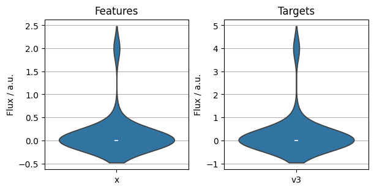

### Polynomial surrogate

We can train our polynomial surrogate using `train_polynomial_surrogate`.  
By default this will train polynomials for the degrees `(1, 2, 3, 4, 5, 6, 7)`, but you can change that by using the `degrees` argument.  
The function returns the trained surrogate and the training information for the different polynomial degrees.

> **Currently the polynomial surrogates are limited to a single feature and a single target**

```python
surrogate, info = train_polynomial_surrogate(
    surrogate_features["x"],
    surrogate_targets["v3"],
)

print("Model", surrogate.model, end="\n\n")
print(info["score"])
```

surrogate, info = train_polynomial_surrogate( surrogate_features["x"], surrogate_targets["v3"], ) print("Model", surrogate.model, end="\n\n") print(info["score"])

```
Model 2.0 + 2.0·(-1.0 + 1.0x)

degree
1     2.0
2     4.0
3     6.0
4     8.0
5    10.0
6    12.0
7    14.0
Name: score, dtype: float64
```

You can then insert the surrogate into the model using the function we defined earlier

```python
concs, fluxes = unwrap(
    Simulator(get_model_with_surrogate(surrogate)).simulate(10).get_result()
)

fig, (ax1, ax2) = plot.two_axes(figsize=(8, 3))
plot.lines(concs, ax=ax1)
plot.lines(fluxes, ax=ax2)
ax1.set(xlabel="time / a.u.", ylabel="concentration / a.u.")
ax2.set(xlabel="time / a.u.", ylabel="flux / a.u.")
plt.show()
```

concs, fluxes = unwrap( Simulator(get_model_with_surrogate(surrogate)).simulate(10).get_result() ) fig, (ax1, ax2) = plot.two_axes(figsize=(8, 3)) plot.lines(concs, ax=ax1) plot.lines(fluxes, ax=ax2) ax1.set(xlabel="time / a.u.", ylabel="concentration / a.u.") ax2.set(xlabel="time / a.u.", ylabel="flux / a.u.") plt.show()

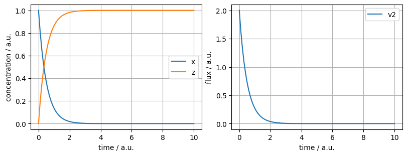

While polynomial regression can model nonlinear relationships between variables, it often struggles when the underlying relationship is more complex than a polynomial function.  
You will learn about using neural networks in the next section.

### Neural network surrogate using PyTorch

Neural networks are designed to capture highly complex and nonlinear relationships.  
Through layers of neurons and activation functions, neural networks can learn intricate patterns that are not easily represented by e.g. a polynomial.  
They have the flexibility to approximate any continuous function, given sufficient depth and appropriate training.

You can train a neural network surrogate based on the popular [PyTorch](https://pytorch.org/) library using `train_torch_surrogate`.  
That function takes the `features`, `targets` and the number of `epochs` as inputs for it's training.

`train_torch_surrogate` returns the trained surrogate, as well as the training `loss`.  
It is always a good idea to check whether that training loss approaches 0.

```python
surrogate, loss = train_torch_surrogate(
    features=surrogate_features,
    targets=surrogate_targets,
    epochs=250,
)

ax = loss.plot(ax=plt.subplots(figsize=(4, 2.5))[1])
ax.set_ylim(0, None)
plt.show()
```

surrogate, loss = train_torch_surrogate( features=surrogate_features, targets=surrogate_targets, epochs=250, ) ax = loss.plot(ax=plt.subplots(figsize=(4, 2.5))[1]) ax.set_ylim(0, None) plt.show()

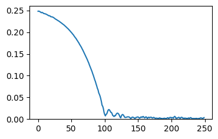

As before, you can then insert the surrogate into the model using the function we defined earlier

```python
concs, fluxes = unwrap(
    Simulator(get_model_with_surrogate(surrogate)).simulate(10).get_result()
)

fig, (ax1, ax2) = plot.two_axes(figsize=(8, 3))
plot.lines(concs, ax=ax1)
plot.lines(fluxes, ax=ax2)
ax1.set(xlabel="time / a.u.", ylabel="concentration / a.u.")
ax2.set(xlabel="time / a.u.", ylabel="flux / a.u.")
plt.show()
```

concs, fluxes = unwrap( Simulator(get_model_with_surrogate(surrogate)).simulate(10).get_result() ) fig, (ax1, ax2) = plot.two_axes(figsize=(8, 3)) plot.lines(concs, ax=ax1) plot.lines(fluxes, ax=ax2) ax1.set(xlabel="time / a.u.", ylabel="concentration / a.u.") ax2.set(xlabel="time / a.u.", ylabel="flux / a.u.") plt.show()

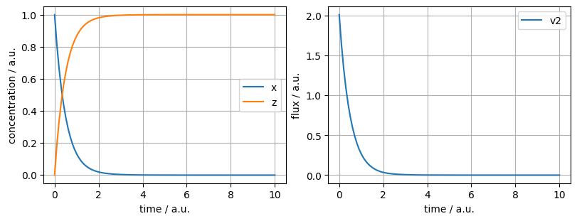

### Troubleshooting

It often can make sense to check specific predictions of the surrogate.  
For example, what does it predict when the inputs are all 0?

```python
print(surrogate.predict(np.array([-0.1])))
print(surrogate.predict(np.array([0.0])))
print(surrogate.predict(np.array([0.1])))
```

print(surrogate.predict(np.array([-0.1]))) print(surrogate.predict(np.array([0.0]))) print(surrogate.predict(np.array([0.1])))

```
{'v2': np.float32(0.00094694644)}
{'v2': np.float32(0.0006899121)}
{'v2': np.float32(0.2007707)}
```

## Neural posterior estimation

**Neural posterior estimation** answers the question: **what parameters could have generated the data I measured?**  
Here you use an ODE model and prior knowledge about the parameters of interest to create *synthetic data*.  
You then use the generated synthetic data as the *features* and the input parameters as the *targets* to train an *inverse problem*.  
Once that training is successful, the neural network can now predict the input parameters for real world data.

[figure not shown]

You can use this technique for both steady-state as well as time course data.  
The only difference is in using `scan.time_course`.

> Take care here to save the targets as well in case you use cached data :)

```python
# Note that now the parameters are the targets
npe_targets = sample(
    {
        "k1": LogNormal(mean=1.0, sigma=0.3),
    },
    n=1_000,
)

# And the generated data are the features
npe_features = scan.steady_state(
    get_linear_chain_2v(),
    parameters=npe_targets,
).results.loc[:, ["y", "v2", "v3"]]

# It's always a good idea to check the inputs and outputs
fig, (ax1, ax2) = plot.two_axes(figsize=(6, 3), sharex=False)
_ = plot.violins(npe_features, ax=ax1)[1].set(title="Features", ylabel="Flux / a.u.")
_ = plot.violins(npe_targets, ax=ax2)[1].set(title="Targets", ylabel="Flux / a.u.")
plt.show()
```

# Note that now the parameters are the targets npe_targets = sample( { "k1": LogNormal(mean=1.0, sigma=0.3), }, n=1_000, ) # And the generated data are the features npe_features = scan.steady_state( get_linear_chain_2v(), parameters=npe_targets, ).results.loc[:, ["y", "v2", "v3"]] # It's always a good idea to check the inputs and outputs fig, (ax1, ax2) = plot.two_axes(figsize=(6, 3), sharex=False) _ = plot.violins(npe_features, ax=ax1)[1].set(title="Features", ylabel="Flux / a.u.") _ = plot.violins(npe_targets, ax=ax2)[1].set(title="Targets", ylabel="Flux / a.u.") plt.show()

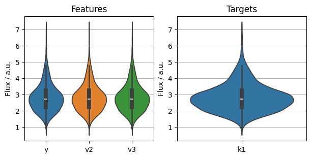

### Train NPE

You can then train your neural posterior estimator using `npe.train_torch_ss_estimator` (or `npe.train_torch_time_course_estimator` if you have time course data).

```python
estimator, losses = npe.train_torch_ss_estimator(
    features=npe_features,
    targets=npe_targets,
    epochs=1000,
)

ax = losses.plot(figsize=(4, 2.5))
ax.set(xlabel="epoch", ylabel="loss")
ax.set_ylim(0, None)
plt.show()
```

estimator, losses = npe.train_torch_ss_estimator( features=npe_features, targets=npe_targets, epochs=1000, ) ax = losses.plot(figsize=(4, 2.5)) ax.set(xlabel="epoch", ylabel="loss") ax.set_ylim(0, None) plt.show()

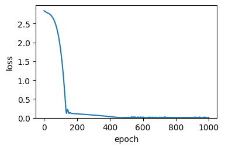

### Sanity check: do prior and posterior match?

```python
fig, (ax1, ax2) = plot.two_axes(figsize=(6, 2))

ax = sns.kdeplot(npe_targets, fill=True, ax=ax1)
ax.set_title("Prior")

posterior = estimator.predict(npe_features)
ax = sns.kdeplot(posterior, fill=True, ax=ax2)
ax.set_title("Posterior")
plt.show()
```

fig, (ax1, ax2) = plot.two_axes(figsize=(6, 2)) ax = sns.kdeplot(npe_targets, fill=True, ax=ax1) ax.set_title("Prior") posterior = estimator.predict(npe_features) ax = sns.kdeplot(posterior, fill=True, ax=ax2) ax.set_title("Posterior") plt.show()

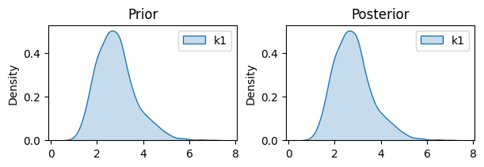

## First finish line

```python
from typing import TYPE_CHECKING

from mxlpy import LinearLabelMapper, Simulator
from mxlpy.distributions import sample
from mxlpy.fns import michaelis_menten_1s
from mxlpy.parallel import parallelise

if TYPE_CHECKING:
    from mxlpy.npe import AbstractEstimator

# FIXME: todo
# Show how to change Adam settings or user other optimizers
# Show how to change the surrogate network
```

from typing import TYPE_CHECKING from mxlpy import LinearLabelMapper, Simulator from mxlpy.distributions import sample from mxlpy.fns import michaelis_menten_1s from mxlpy.parallel import parallelise if TYPE_CHECKING: from mxlpy.npe import AbstractEstimator # FIXME: todo # Show how to change Adam settings or user other optimizers # Show how to change the surrogate network

## Label NPE

```python
def get_closed_cycle() -> tuple[Model, dict[str, int], dict[str, list[int]]]:
    """

    | Reaction       | Labelmap |
    | -------------- | -------- |
    | x1 ->[v1] x2   | [0, 1]   |
    | x2 ->[v2a] x3  | [0, 1]   |
    | x2 ->[v2b] x3  | [1, 0]   |
    | x3 ->[v3] x1   | [0, 1]   |

    """
    model = (
        Model()
        .add_parameters(
            {
                "vmax_1": 1.0,
                "km_1": 0.5,
                "vmax_2a": 1.0,
                "vmax_2b": 1.0,
                "km_2": 0.5,
                "vmax_3": 1.0,
                "km_3": 0.5,
            }
        )
        .add_variables({"x1": 1.0, "x2": 0.0, "x3": 0.0})
        .add_reaction(
            "v1",
            michaelis_menten_1s,
            stoichiometry={"x1": -1, "x2": 1},
            args=["x1", "vmax_1", "km_1"],
        )
        .add_reaction(
            "v2a",
            michaelis_menten_1s,
            stoichiometry={"x2": -1, "x3": 1},
            args=["x2", "vmax_2a", "km_2"],
        )
        .add_reaction(
            "v2b",
            michaelis_menten_1s,
            stoichiometry={"x2": -1, "x3": 1},
            args=["x2", "vmax_2b", "km_2"],
        )
        .add_reaction(
            "v3",
            michaelis_menten_1s,
            stoichiometry={"x3": -1, "x1": 1},
            args=["x3", "vmax_3", "km_3"],
        )
    )
    label_variables: dict[str, int] = {"x1": 2, "x2": 2, "x3": 2}
    label_maps: dict[str, list[int]] = {
        "v1": [0, 1],
        "v2a": [0, 1],
        "v2b": [1, 0],
        "v3": [0, 1],
    }
    return model, label_variables, label_maps
```

def get_closed_cycle() -> tuple[Model, dict[str, int], dict[str, list[int]]]: """ | Reaction | Labelmap | | -------------- | -------- | | x1 ->[v1] x2 | [0, 1] | | x2 ->[v2a] x3 | [0, 1] | | x2 ->[v2b] x3 | [1, 0] | | x3 ->[v3] x1 | [0, 1] | """ model = ( Model() .add_parameters( { "vmax_1": 1.0, "km_1": 0.5, "vmax_2a": 1.0, "vmax_2b": 1.0, "km_2": 0.5, "vmax_3": 1.0, "km_3": 0.5, } ) .add_variables({"x1": 1.0, "x2": 0.0, "x3": 0.0}) .add_reaction( "v1", michaelis_menten_1s, stoichiometry={"x1": -1, "x2": 1}, args=["x1", "vmax_1", "km_1"], ) .add_reaction( "v2a", michaelis_menten_1s, stoichiometry={"x2": -1, "x3": 1}, args=["x2", "vmax_2a", "km_2"], ) .add_reaction( "v2b", michaelis_menten_1s, stoichiometry={"x2": -1, "x3": 1}, args=["x2", "vmax_2b", "km_2"], ) .add_reaction( "v3", michaelis_menten_1s, stoichiometry={"x3": -1, "x1": 1}, args=["x3", "vmax_3", "km_3"], ) ) label_variables: dict[str, int] = {"x1": 2, "x2": 2, "x3": 2} label_maps: dict[str, list[int]] = { "v1": [0, 1], "v2a": [0, 1], "v2b": [1, 0], "v3": [0, 1], } return model, label_variables, label_maps

```python
def _worker(
    x: tuple[tuple[int, pd.Series], tuple[int, pd.Series]],
    mapper: LinearLabelMapper,
    time: float,
    initial_labels: dict[str, int | list[int]],
) -> pd.Series:
    (_, y_ss), (_, v_ss) = x
    return unwrap(
        Simulator(mapper.build_model(y_ss, v_ss, initial_labels=initial_labels))
        .simulate(time)
        .get_result()
    ).variables.iloc[-1]


def get_label_distribution_at_time(
    model: Model,
    label_variables: dict[str, int],
    label_maps: dict[str, list[int]],
    time: float,
    initial_labels: dict[str, int | list[int]],
    ss_concs: pd.DataFrame,
    ss_fluxes: pd.DataFrame,
) -> pd.DataFrame:
    mapper = LinearLabelMapper(
        model,
        label_variables=label_variables,
        label_maps=label_maps,
    )

    return pd.DataFrame(
        parallelise(
            partial(_worker, mapper=mapper, time=time, initial_labels=initial_labels),
            inputs=list(
                enumerate(zip(ss_concs.iterrows(), ss_fluxes.iterrows(), strict=True))
            ),
            cache=None,
        )
    ).T


def inverse_parameter_elasticity(
    estimator: AbstractEstimator,
    datum: pd.Series,
    *,
    normalized: bool = True,
    displacement: float = 1e-4,
) -> pd.DataFrame:
    ref = estimator.predict(datum).iloc[0, :]

    coefs = {}
    for name, value in datum.items():
        up = coefs[name] = estimator.predict(
            pd.Series(datum.to_dict() | {name: value * 1 + displacement})
        ).iloc[0, :]
        down = coefs[name] = estimator.predict(
            pd.Series(datum.to_dict() | {name: value * 1 - displacement})
        ).iloc[0, :]
        coefs[name] = (up - down) / (2 * displacement * value)

    coefs = pd.DataFrame(coefs)
    if normalized:
        coefs *= datum / ref.to_numpy()

    return coefs
```

def _worker( x: tuple[tuple[int, pd.Series], tuple[int, pd.Series]], mapper: LinearLabelMapper, time: float, initial_labels: dict[str, int | list[int]], ) -> pd.Series: (_, y_ss), (_, v_ss) = x return unwrap( Simulator(mapper.build_model(y_ss, v_ss, initial_labels=initial_labels)) .simulate(time) .get_result() ).variables.iloc[-1] def get_label_distribution_at_time( model: Model, label_variables: dict[str, int], label_maps: dict[str, list[int]], time: float, initial_labels: dict[str, int | list[int]], ss_concs: pd.DataFrame, ss_fluxes: pd.DataFrame, ) -> pd.DataFrame: mapper = LinearLabelMapper( model, label_variables=label_variables, label_maps=label_maps, ) return pd.DataFrame( parallelise( partial(_worker, mapper=mapper, time=time, initial_labels=initial_labels), inputs=list( enumerate(zip(ss_concs.iterrows(), ss_fluxes.iterrows(), strict=True)) ), cache=None, ) ).T def inverse_parameter_elasticity( estimator: AbstractEstimator, datum: pd.Series, *, normalized: bool = True, displacement: float = 1e-4, ) -> pd.DataFrame: ref = estimator.predict(datum).iloc[0, :] coefs = {} for name, value in datum.items(): up = coefs[name] = estimator.predict( pd.Series(datum.to_dict() | {name: value * 1 + displacement}) ).iloc[0, :] down = coefs[name] = estimator.predict( pd.Series(datum.to_dict() | {name: value * 1 - displacement}) ).iloc[0, :] coefs[name] = (up - down) / (2 * displacement * value) coefs = pd.DataFrame(coefs) if normalized: coefs *= datum / ref.to_numpy() return coefs

```python
model, label_variables, label_maps = get_closed_cycle()

ss_concs, ss_fluxes = unwrap(
    Simulator(model)
    .update_parameters({"vmax_2a": 1.0, "vmax_2b": 0.5})
    .simulate_to_steady_state()
    .get_result()
)
mapper = LinearLabelMapper(
    model,
    label_variables=label_variables,
    label_maps=label_maps,
)

_, axs = plot.relative_label_distribution(
    mapper,
    unwrap(
        Simulator(
            mapper.build_model(
                ss_concs.iloc[-1], ss_fluxes.iloc[-1], initial_labels={"x1": 0}
            )
        )
        .simulate(5)
        .get_result()
    ).variables,
    sharey=True,
    n_cols=3,
)

axs[0].set_ylabel("Relative label distribution")
axs[1].set_xlabel("Time / s")
plt.show()
```

model, label_variables, label_maps = get_closed_cycle() ss_concs, ss_fluxes = unwrap( Simulator(model) .update_parameters({"vmax_2a": 1.0, "vmax_2b": 0.5}) .simulate_to_steady_state() .get_result() ) mapper = LinearLabelMapper( model, label_variables=label_variables, label_maps=label_maps, ) _, axs = plot.relative_label_distribution( mapper, unwrap( Simulator( mapper.build_model( ss_concs.iloc[-1], ss_fluxes.iloc[-1], initial_labels={"x1": 0} ) ) .simulate(5) .get_result() ).variables, sharey=True, n_cols=3, ) axs[0].set_ylabel("Relative label distribution") axs[1].set_xlabel("Time / s") plt.show()

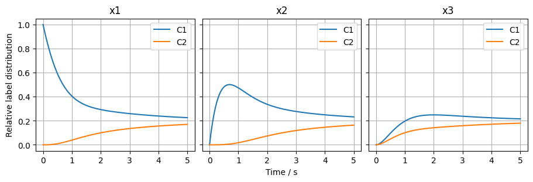

```python
surrogate_targets = sample(
    {
        "vmax_2b": Normal(0.5, 0.1),
    },
    n=1000,
).clip(lower=0)

ax = sns.kdeplot(surrogate_targets, fill=True)
ax.set_title("Prior")
```

surrogate_targets = sample( { "vmax_2b": Normal(0.5, 0.1), }, n=1000, ).clip(lower=0) ax = sns.kdeplot(surrogate_targets, fill=True) ax.set_title("Prior")

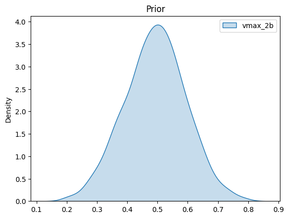

```python
ss_concs, ss_fluxes = scan.steady_state(model, parameters=surrogate_targets)
```

ss_concs, ss_fluxes = scan.steady_state(model, parameters=surrogate_targets)

```python
fig, (ax1, ax2) = plt.subplots(1, 2, figsize=(12, 4))
_, ax = plot.violins(ss_concs, ax=ax1)
ax.set_ylabel("Concentration / a.u.")
_, ax = plot.violins(ss_fluxes, ax=ax2)
ax.set_ylabel("Flux / a.u.")
```

fig, (ax1, ax2) = plt.subplots(1, 2, figsize=(12, 4)) _, ax = plot.violins(ss_concs, ax=ax1) ax.set_ylabel("Concentration / a.u.") _, ax = plot.violins(ss_fluxes, ax=ax2) ax.set_ylabel("Flux / a.u.")

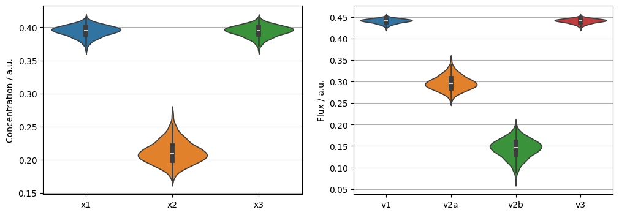

```python
surrogate_features = get_label_distribution_at_time(
    model=model,
    label_variables=label_variables,
    label_maps=label_maps,
    time=5,
    ss_concs=ss_concs,
    ss_fluxes=ss_fluxes,
    initial_labels={"x1": 0},
)
_, ax = plot.violins(surrogate_features)
ax.set_ylabel("Relative label distribution")
```

surrogate_features = get_label_distribution_at_time( model=model, label_variables=label_variables, label_maps=label_maps, time=5, ss_concs=ss_concs, ss_fluxes=ss_fluxes, initial_labels={"x1": 0}, ) _, ax = plot.violins(surrogate_features) ax.set_ylabel("Relative label distribution")

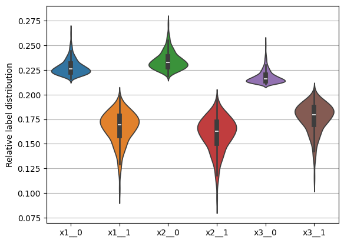

```python
estimator, losses = npe.train_torch_ss_estimator(
    features=surrogate_features,
    targets=surrogate_targets,
    epochs=2_000,
)

ax = losses.plot()
ax.set_ylim(0, None)
```

estimator, losses = npe.train_torch_ss_estimator( features=surrogate_features, targets=surrogate_targets, epochs=2_000, ) ax = losses.plot() ax.set_ylim(0, None)

```
(0.0, 0.5147218400496059)
```

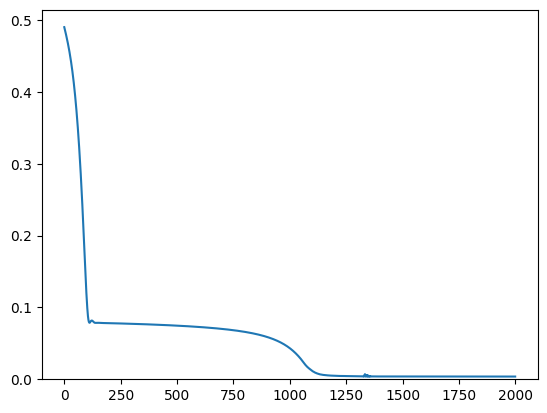

```python
fig, (ax1, ax2) = plt.subplots(
    1,
    2,
    figsize=(8, 3),
    layout="constrained",
    sharex=True,
    sharey=False,
)

ax = sns.kdeplot(surrogate_targets, fill=True, ax=ax1)
ax.set_title("Prior")

posterior = estimator.predict(surrogate_features)

ax = sns.kdeplot(posterior, fill=True, ax=ax2)
ax.set_title("Posterior")
ax2.set_ylim(*ax1.get_ylim())
plt.show()
```

fig, (ax1, ax2) = plt.subplots( 1, 2, figsize=(8, 3), layout="constrained", sharex=True, sharey=False, ) ax = sns.kdeplot(surrogate_targets, fill=True, ax=ax1) ax.set_title("Prior") posterior = estimator.predict(surrogate_features) ax = sns.kdeplot(posterior, fill=True, ax=ax2) ax.set_title("Posterior") ax2.set_ylim(*ax1.get_ylim()) plt.show()

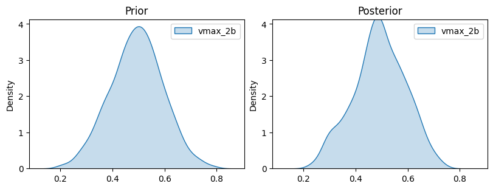

### Inverse parameter sensitivity

```python
_ = plot.heatmap(inverse_parameter_elasticity(estimator, surrogate_features.iloc[0]))
```

_ = plot.heatmap(inverse_parameter_elasticity(estimator, surrogate_features.iloc[0]))

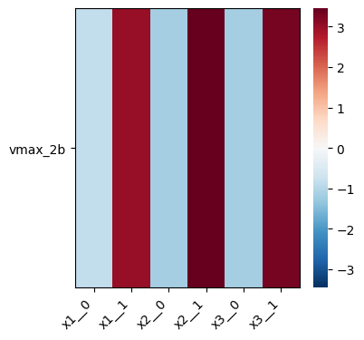

```python
elasticities = pd.DataFrame(
    {
        k: inverse_parameter_elasticity(estimator, i).loc["vmax_2b"]
        for k, i in surrogate_features.iterrows()
    }
).T

_ = plot.violins(elasticities)
```

elasticities = pd.DataFrame( { k: inverse_parameter_elasticity(estimator, i).loc["vmax_2b"] for k, i in surrogate_features.iterrows() } ).T _ = plot.violins(elasticities)

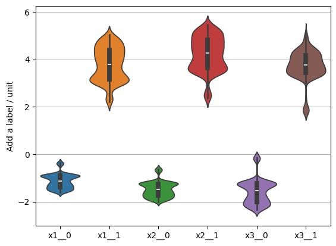